# Data Analysis Script for Watershed Properties STR Conversion Feasibility Project

# 1 Data

## 1.1 Retrieval

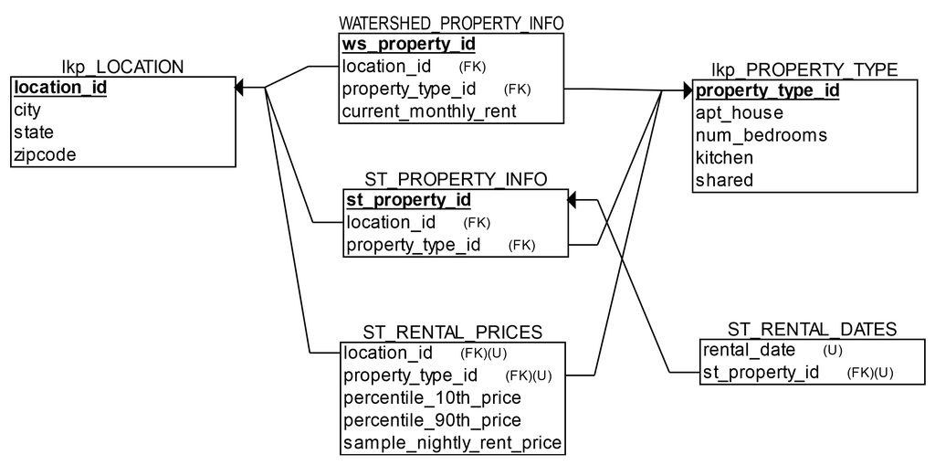

Watershed Properties relational schema for database

## 1.2 Data dictionary

| Variable name | Abbreviation in R | Description |
| --- | --- | --- |
| ws_property_id |  | Watershed property ID |
| location |  | Location of the property (not unique since one location ID can have multiple properties) |
| property_type |  | Type of property (R1 to R16, 16 combinations of apartment/house, one/two BR, whether there is a kitchen (Y/N), and whether property is shared with owner (Y/N)itchen) |
| current_monthly_rent | lt_monthly | Current long-term rental rate (monthly rate) |
| percentile_10th_price | p10 | 10th percentile of short-term rental price for similar property in similar location |
| percentile_90th_price | p90 | 90th percentile of short-term rental price for similar property in similar location |
| sample_nightly_rent_price | st_samp | Example short-term rental of similar property (nightly rate) |
| count | nights_per_year | Number of nights the property was occupied in 2015 |
| occ_rate |  | Occupancy rate in 2015 |
| city |  | City (United States) |
| state |  | State |
| zipcode |  | Zip code |
| apt_house |  | Apartment or House type |
| num_bedrooms |  | Number of bedrooms |
| kitchen |  | Whether there is a kitchen (Y/N) |
| shared |  | Whether property is shared with owner (Y/N) |

## 1.3 Data cleaning and name change

The names “short-term rate (STR) rate” and “nightly rental rate” will be used interchangeably.

```r
ws_data <- ws_data %>%
  rename(
    p90 = percentile_90th_price,
    p10 = percentile_10th_price,
    nights_per_year = count...,
    st_samp = sample_nightly_rent_price,
    lt_monthly = current_monthly_rent)
head(ws_data)
```

|  | ws_property_id | location | property_type | lt_monthly | p10 | p90 | st_samp | nights_per_year | occ_rate | city | state | zipcode | apt_house | num_bedrooms | kitchen | shared |
| --- | --- | --- | --- | --- | --- | --- | --- | --- | --- | --- | --- | --- | --- | --- | --- | --- |
| 1 | W1 | L9531 | R6 | 1060 | 114 | 153 | 148 | 59 | 0.16 | Chapel Hill | NC | 27514 | apartment | 2 | Y | N |
| 2 | W10 | L9533 | R6 | 1200 | 111 | 149 | 133 | 127 | 0.35 | Chapel Hill | NC | 27517 | apartment | 2 | Y | N |
| 3 | W100 | L1944 | R2 | 3300 | 108 | 610 | 372 | 145 | 0.40 | San Francisco | CA | 94129 | apartment | 1 | Y | N |
| 4 | W101 | L15257 | R2 | 1400 | 178 | 533 | 302 | 133 | 0.36 | Austin | TX | 78702 | apartment | 1 | Y | N |
| 5 | W102 | L15257 | R6 | 2000 | 221 | 617 | 429 | 150 | 0.41 | Austin | TX | 78702 | apartment | 2 | Y | N |
| 6 | W103 | L15257 | R10 | 1600 | 202 | 646 | 380 | 150 | 0.41 | Austin | TX | 78702 | house | 1 | Y | N |

# 2 Modeling

## 2.1 Normalizing STR rate for simple linear regression

The relationship between short-term (ST) occupancy rate `occ_rate` and STR rate `st_samp` is not statistically significant when ST rate is input at the original scale. We normalize the example ST rate to percentile using the 10th and 90th percentile prices of its corresponding location, then add 0.1 to ensure that the normalized data falls between 10th and 90th percentiles again. Regressing the ST occupancy rate against the normalized ST rate will give significant coefficient.

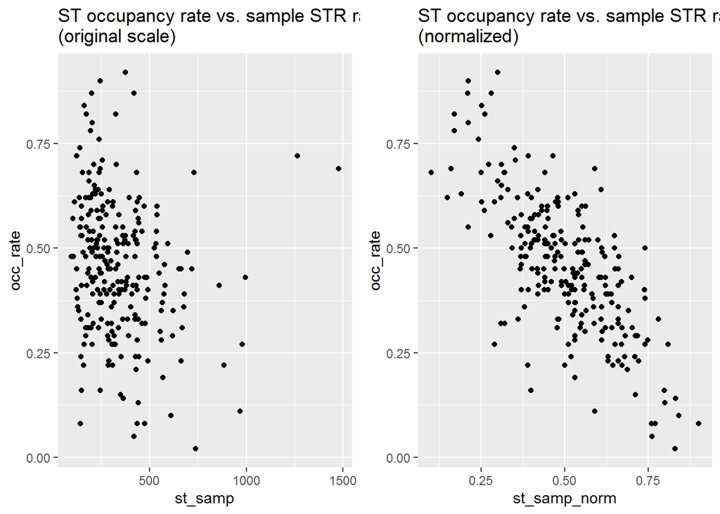

```r
# occ_rate v. st_nightly on original scale
ggp1 <- ggplot(data = ws_data) +
  geom_point(aes(x = st_samp, y = occ_rate)) +
  labs(title = "ST occupancy rate vs. sample STR rate\n(original scale)")

# normalizing STR rate
ws_data <- ws_data %>%
  mutate(st_samp_norm = 0.1 + 0.8 * (st_samp - p10) / (p90 - p10))

# occ_rate v. st_nightly normalized
ggp2 <- ggplot(data = ws_data) +
  geom_point(aes(x = st_samp_norm, y = occ_rate)) +
  labs(title = "ST occupancy rate vs. sample STR rate\n(normalized)")

grid.arrange(ggp1, ggp2, ncol = 2)
```

- Simple linear regression model $Y=\alpha+\beta X$, where $Y=$ occupancy rate, $X=$ sample STR rate percentile, $\alpha=$ occupancy rate at 0th STR rate percentile, and $\beta=$ change in occupancy rate per one percentile increase in STR rate.

```r
# simple linear regression
mod1 <- lm(occ_rate ~ st_samp_norm, data = ws_data)
summary(mod1)
```

```
##
## Call:
## lm(formula = occ_rate ~ st_samp_norm, data = ws_data)
##
## Residuals:
##      Min       1Q   Median       3Q      Max
## -0.37493 -0.06930  0.00154  0.07194  0.30655
##
## Coefficients:
##              Estimate Std. Error t value Pr(>|t|)
## (Intercept)   0.85167    0.02560   33.27   <2e-16 ***
## st_samp_norm -0.79359    0.04922  -16.12   <2e-16 ***
## ---
## Signif. codes:  0 '***' 0.001 '**' 0.01 '*' 0.05 '.' 0.1 ' ' 1
##
## Residual standard error: 0.114 on 242 degrees of freedom
## Multiple R-squared:  0.5179, Adjusted R-squared:  0.5159
## F-statistic:   260 on 1 and 242 DF,  p-value: < 2.2e-16
```

```r
# intercept
alpha <- mod1$coefficients[1]; alpha
```

```
## (Intercept)
##   0.8516725
```

```r
#slope
beta <- mod1$coefficients[2]; beta
```

```
## st_samp_norm
##   -0.7935938
```

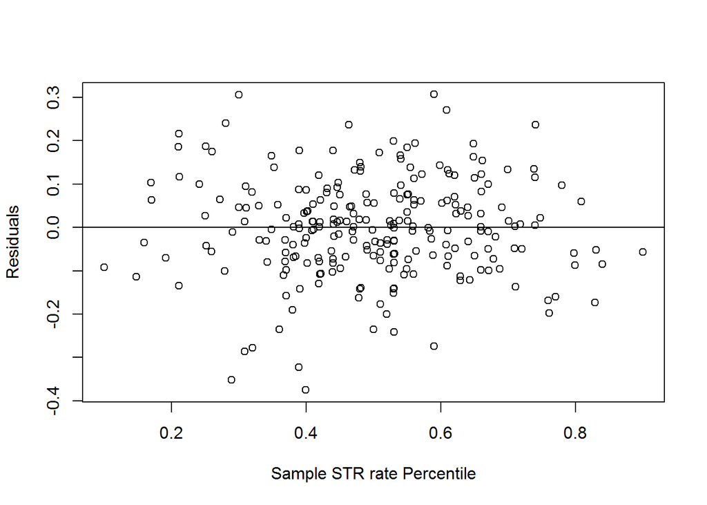

```r
# quick check if residual of the model. No pattern in the residual means the model explained the original pattern in the data.

mod1_resid <- resid(mod1);
plot(ws_data$st_samp_norm, mod1_resid, ylab="Residuals", xlab="Sample STR rate Percentile")
abline(0,0);
```

## 2.2 Predict occupancy rate using linear model

```r
ws_data <- ws_data %>%
  mutate(
    # pred_occ_rate = alpha + beta * norm_rental_rate,
    pred_occ_rate = predict(mod1)
    )
head(ws_data)
```

|  | ws_property_id | location | property_type | lt_monthly | p10 | p90 | st_samp | nights_per_year | occ_rate | city | state | zipcode | apt_house | num_bedrooms | kitchen | shared | st_samp_norm | pred_occ_rate |
| --- | --- | --- | --- | --- | --- | --- | --- | --- | --- | --- | --- | --- | --- | --- | --- | --- | --- | --- |
| 1 | W1 | L9531 | R6 | 1060 | 114 | 153 | 148 | 59 | 0.16 | Chapel Hill | NC | 27514 | apartment | 2 | Y | N | 0.7974359 | 0.2188324 |
| 2 | W10 | L9533 | R6 | 1200 | 111 | 149 | 133 | 127 | 0.35 | Chapel Hill | NC | 27517 | apartment | 2 | Y | N | 0.5631579 | 0.4047539 |
| 3 | W100 | L1944 | R2 | 3300 | 108 | 610 | 372 | 145 | 0.40 | San Francisco | CA | 94129 | apartment | 1 | Y | N | 0.5207171 | 0.4384347 |
| 4 | W101 | L15257 | R2 | 1400 | 178 | 533 | 302 | 133 | 0.36 | Austin | TX | 78702 | apartment | 1 | Y | N | 0.3794366 | 0.5505540 |
| 5 | W102 | L15257 | R6 | 2000 | 221 | 617 | 429 | 150 | 0.41 | Austin | TX | 78702 | apartment | 2 | Y | N | 0.5202020 | 0.4388435 |
| 6 | W103 | L15257 | R10 | 1600 | 202 | 646 | 380 | 150 | 0.41 | Austin | TX | 78702 | house | 1 | Y | N | 0.4207207 | 0.5177912 |

## 2.3 Optimize rental rate and occupancy rate

For each property, find the STR rate (normalized) that maximizes revenue for that property, using the predicted occupancy rate. If nightly rental rate is less than 10-th percentile of the sample rate, use the 10-th percentile instead.

Note: in Excel, Solver can be used for individual property but it is tedious to apply Solver to 244 data points. When replicating the analysis in Excel and Tableau, I used the analytic approach where optimal STR rate $X^*$ is computed using

where

- $P_{10}$ is `p10`, 10th percentile of sample STR rate
- $P_{90}$ is `p90`, 90th percentile of sample STR rate
- $r$ is the range $P_{90}-P_{10}$

In R, I use the `optim` function and loop through the data set.

```r
rev <- function(st_raw, data){
  r <- data$p90 - data$p10
  st_norm <- 0.1 + 0.8*((st_raw - data$p10)/ r)
  pred_occ <- alpha + (beta*st_norm)
  revenue <- (st_raw * pred_occ * 365)
  revenue
}

for (i in 1:nrow(ws_data)){
  ws_data[i,'optim_st_adj'] <- optim(
    par = 1,
    fn = rev,
    data = ws_data[i,],
    method = "L-BFGS-B",
    control = list(fnscale =-1), #set = -1 to find max
    lower = ws_data[i,'p10'])[1]
  }
```

Convert this optimal STR rate back to percentile and find corresponding optimal occupancy rate.

```r
ws_data <- ws_data %>%
  mutate(
    optim_st_rent_norm = 0.8*(optim_st_adj - p10)/(p90-p10) + .1,
    optim_occ_rate = beta * optim_st_rent_norm + alpha
  )
head(ws_data)
```

|  | ws_property_id | location | property_type | lt_monthly | p10 | p90 | st_samp | nights_per_year | occ_rate | city | state | zipcode | apt_house | num_bedrooms | kitchen | shared | st_samp_norm | pred_occ_rate | optim_st_adj | optim_st_rent_norm | optim_occ_rate |
| --- | --- | --- | --- | --- | --- | --- | --- | --- | --- | --- | --- | --- | --- | --- | --- | --- | --- | --- | --- | --- | --- |
| 1 | W1 | L9531 | R6 | 1060 | 114 | 153 | 148 | 59 | 0.16 | Chapel Hill | NC | 27514 | apartment | 2 | Y | N | 0.7974359 | 0.2188324 | 114.0000 | 0.1000000 | 0.7723132 |
| 2 | W10 | L9533 | R6 | 1200 | 111 | 149 | 133 | 127 | 0.35 | Chapel Hill | NC | 27517 | apartment | 2 | Y | N | 0.5631579 | 0.4047539 | 111.0000 | 0.1000000 | 0.7723132 |
| 3 | W100 | L1944 | R2 | 3300 | 108 | 610 | 372 | 145 | 0.40 | San Francisco | CA | 94129 | apartment | 1 | Y | N | 0.5207171 | 0.4384347 | 359.3366 | 0.5005365 | 0.4544499 |
| 4 | W101 | L15257 | R2 | 1400 | 178 | 533 | 302 | 133 | 0.36 | Austin | TX | 78702 | apartment | 1 | Y | N | 0.3794366 | 0.5505540 | 304.9253 | 0.3860289 | 0.5453224 |
| 5 | W102 | L15257 | R6 | 2000 | 221 | 617 | 429 | 150 | 0.41 | Austin | TX | 78702 | apartment | 2 | Y | N | 0.5202020 | 0.4388435 | 351.3632 | 0.3633599 | 0.5633124 |
| 6 | W103 | L15257 | R10 | 1600 | 202 | 646 | 380 | 150 | 0.41 | Austin | TX | 78702 | house | 1 | Y | N | 0.4207207 | 0.5177912 | 371.0587 | 0.4046103 | 0.5305763 |

# 3 Financial forecast

## 3.1 Financial assumptions

- `cap_expend`: Capital expenditure or cost of converting one long-term rental property to short-term rental.
- `deprec_years`: depreciation period in years using straight line depreciation method
- `ann_utility`: annual utility (12 months)
- `cost_per_visit`: hospitality cost per visit (cleaning, keys, restocking toiletries, etc.)
- `days_per_visit`: average length per guest visit
- `trnsct_fees`: transaction fees paid to internet booking services like Airnbn (Hotel Occupancy Tax included)
- `cutoff`: threshold to consider whether a conversion is profitable or not

Initial assumptions using information obtained from Watershed managers:

```r
cap_expend <- 30000
deprec_years <- 5
ann_utility <- 300 * 12
ann_repair <- 6000
cost_per_visit <- 100
days_per_visit <- 3
trnsct_fees <- .3
cutoff <- 6000
```

## 3.2 Calculated variables

- `optim_st_rev_net` : net SRT revenue using optimal STR rate and occupancy rate calculated above, excluding transaction fees.
- `lt_annual_rev`: annual revenue if properties are kept as long-term rentals where occupancy rate is 0.973 (yearly)
- `gross_rev_change`: gross revenue change if convert LTR to STR
- `variable_cost`: variable cost per guest visit
- `new_cash_out_yc`: new cash outflow during conversion year
- `new_cash_out_yx`: new cash outflow after conversion year
- `new_change_profit_yc`: new change in profit during conversion year
- `new_change_profit_yx`: new change in profit after conversion year
- `net_change_cashflow_yc`: net change in cash flow during conversion year
- `net_change_cashflow_yx`: net change in cash flow after conversion year
- `net_change_profit_yc`: net change in profit during conversion year
- `net_change_profit_yx`: net change in profit after conversion year
- `net_change_cashflow_sum`: total net change in cash flow durign and after conversion

```r
ws_data <- ws_data %>%
  mutate(
    # after fees
    optim_st_rev_net = optim_st_adj * optim_occ_rate * 365 * (1 - trnsct_fees),
    lt_annual_rev = lt_monthly * 12 * 0.973,
    gross_rev_change = optim_st_rev_net - lt_annual_rev,
    variable_cost = optim_occ_rate * 365/days_per_visit * cost_per_visit,
    new_cash_out_yc = - cap_expend - ann_utility - variable_cost,
    new_cash_out_yx = - ann_utility - variable_cost - ann_repair,
    new_change_profit_yc = - (cap_expend/deprec_years) - ann_utility - variable_cost,
    new_change_profit_yx = - (cap_expend/deprec_years) - ann_utility - variable_cost - ann_repair,
    net_change_cashflow_yc = gross_rev_change + new_cash_out_yc,
    net_change_cashflow_yx = gross_rev_change + new_cash_out_yx,
    net_change_profit_yc = gross_rev_change + new_change_profit_yc,
    net_change_profit_yx = gross_rev_change + new_change_profit_yx,
    net_change_cashflow_sum = net_change_cashflow_yc + net_change_cashflow_yx
    )

head(ws_data)
```

|  | ws_property_id | location | property_type | lt_monthly | p10 | p90 | st_samp | nights_per_year | occ_rate | city | state | zipcode | apt_house | num_bedrooms | kitchen | shared | st_samp_norm | pred_occ_rate | optim_st_adj | optim_st_rent_norm | optim_occ_rate | optim_st_rev_net | lt_annual_rev | gross_rev_change | variable_cost | new_cash_out_yc | new_cash_out_yx | new_change_profit_yc | new_change_profit_yx | … |
| --- | --- | --- | --- | --- | --- | --- | --- | --- | --- | --- | --- | --- | --- | --- | --- | --- | --- | --- | --- | --- | --- | --- | --- | --- | --- | --- | --- | --- | --- | --- |
| 1 | W1 | L9531 | R6 | 1060 | 114 | 153 | 148 | 59 | 0.16 | Chapel Hill | NC | 27514 | apartment | 2 | Y | N | 0.7974359 | 0.2188324 | 114.0000 | 0.1000000 | 0.7723132 | 22495.17 | 12376.56 | 10118.606 | 9396.477 | -42996.48 | -18996.48 | -18996.48 | -24996.48 | … |
| 2 | W10 | L9533 | R6 | 1200 | 111 | 149 | 133 | 127 | 0.35 | Chapel Hill | NC | 27517 | apartment | 2 | Y | N | 0.5631579 | 0.4047539 | 111.0000 | 0.1000000 | 0.7723132 | 21903.19 | 14011.20 | 7891.988 | 9396.477 | -42996.48 | -18996.48 | -18996.48 | -24996.48 | … |
| 3 | W100 | L1944 | R2 | 3300 | 108 | 610 | 372 | 145 | 0.40 | San Francisco | CA | 94129 | apartment | 1 | Y | N | 0.5207171 | 0.4384347 | 359.3366 | 0.5005365 | 0.4544499 | 41723.28 | 38530.80 | 3192.479 | 5529.141 | -39129.14 | -15129.14 | -15129.14 | -21129.14 | … |
| 4 | W101 | L15257 | R2 | 1400 | 178 | 533 | 302 | 133 | 0.36 | Austin | TX | 78702 | apartment | 1 | Y | N | 0.3794366 | 0.5505540 | 304.9253 | 0.3860289 | 0.5453224 | 42485.21 | 16346.40 | 26138.808 | 6634.756 | -40234.76 | -16234.76 | -16234.76 | -22234.76 | … |
| 5 | W102 | L15257 | R6 | 2000 | 221 | 617 | 429 | 150 | 0.41 | Austin | TX | 78702 | apartment | 2 | Y | N | 0.5202020 | 0.4388435 | 351.3632 | 0.3633599 | 0.5633124 | 50570.40 | 23352.00 | 27218.404 | 6853.634 | -40453.63 | -16453.63 | -16453.63 | -22453.63 | … |
| 6 | W103 | L15257 | R10 | 1600 | 202 | 646 | 380 | 150 | 0.41 | Austin | TX | 78702 | house | 1 | Y | N | 0.4207207 | 0.5177912 | 371.0587 | 0.4046103 | 0.5305763 | 50301.56 | 18681.60 | 31619.956 | 6455.346 | -40055.35 | -16055.35 | -16055.35 | -22055.35 | … |

## 3.3 Baseline recommendation

### 3.3.1 Number of profitable properties

Given the financial assumptions obtained from Watershed managers, I obtained the following results:

- Number of properties with at least $6k in net change in profits (after conversion): 41

```r
table(ws_data$net_change_profit_yx > cutoff)
```

```
##
## FALSE  TRUE
##   203    41
```

- Number of properties with positive cash flow by the end of the conversion year: 21

```r
table(ws_data$net_change_cashflow_yc > 0)
```

```
##
## FALSE  TRUE
##   223    21
```

- Number of properties with positive cash flow by the end of the subsequent year: 41

```r
table(ws_data$net_change_cashflow_sum > 0)
```

```
##
## FALSE  TRUE
##   203    41
```

### 3.3.2 Cash flow risk and total cash required

To fund 41 conversions at the same time, Watershed would need for capital expenditure: $1.23m

```r
cap_expend * table(ws_data$net_change_profit_yx > cutoff)[2]
```

```
##    TRUE
## 1230000
```

All 41 properties above the $6k cutoff have positive cash flow after 2 years.

```r
table(ws_data$net_change_cashflow_yx < 0, ws_data$net_change_profit_yx > 6000)
```

```
##
##         FALSE TRUE
##   FALSE    74   41
##   TRUE    129    0
```

## 3.4 Sensitivity Analysis

To examine how the forecast responds to changing financial assumptions, I used Scenario Manager in Excel and created a [sensitivity dashboard in Tableau](https://public.tableau.com/app/profile/mai.nguyen1686/viz/WatershedPropertiesFinancialForecastDashboard/AnalystDboard2).

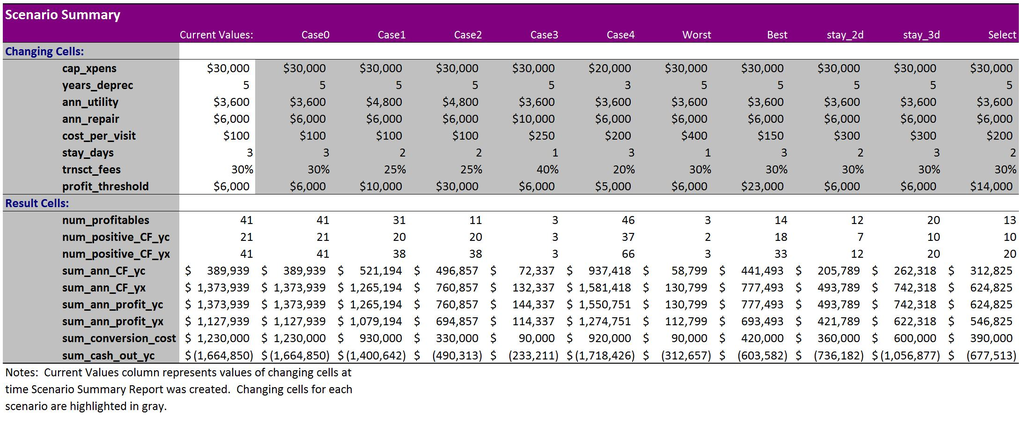

Scenario Summary